# Lab 5: Central Limit Theorem

### Left Skewed

2. Go to the “Population Distribution” tab, download the distribution plot and name it as “pop_LS.png”, then insert the image below.

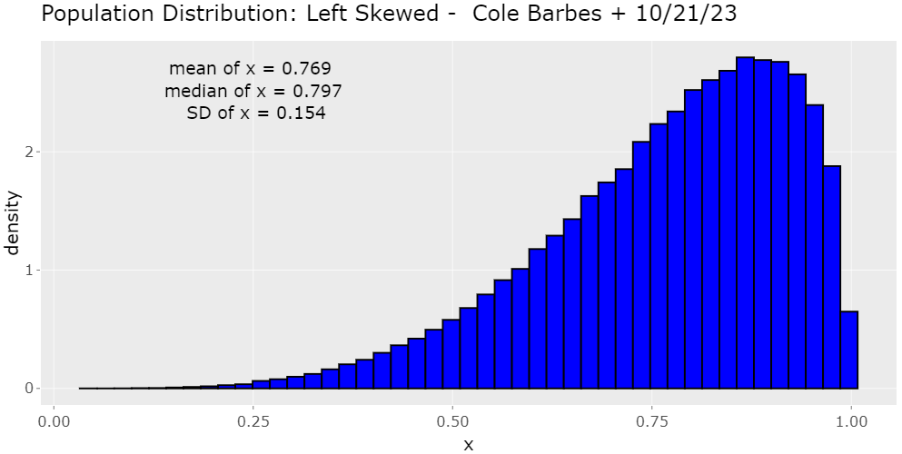

   Population Left skew

3. Based on the population distribution plot, answer the questions: what is the mean and standard deviation of this “parent” distribution, does it satisfy the assumptions? (specify which conditions are satisfied, especially 3a or 3b)

4. Go to the “Sampling Distribution - Sample Mean” tab, download the histogram and QQ-plot (for QQ-plot, you may need to right click you mouse on that plot, and click “Save image as…”). Name the plots as “sample_hist_normal_n5.png” and “sample_qq_normal_n5.png” (n5 means sample size n=5). Then insert the plots below

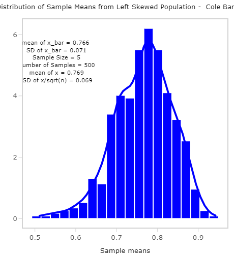

   Sample histogram left skew

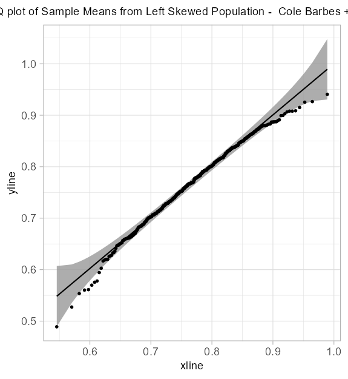

   Sample QQ plot left skew

5. Based on the histogram and QQ_plot, answer the questions: what is the mean and standard deviation of $\overline{X}$? Do they (approximately) equal to the population mean and $\sigma/\sqrt(n)$, respectively? Based on the histogram and QQ_plot, determine whether the sampling distribution of sample means is approximately normal distributed.

   (In the case when the calculation results on the histogram are covered by the image, move you mouse to the plot, use the “pan” pop-up icon and/or “zoom in” pop_up icon to get a clearer view)

   ```
   mean of xbar is 0.766, standard deviation of xbar is 0.071 . mean of x is 0.769, sd/sqrt(n) is 0.069. it seems the means do match and the sd and the sd/sqrt(n) approximately match. The sampling distribution of sample means is a left skew for this low of sample size n.
   ```

6. Keep the Population Distribution as “Normal”and the Number of samples as 500. But change the Sample Size to 30 and 100. Then answer questions 4 and 5 respectively. (when you download the plots, make sure to adjust the name to n30 and n100, respectively)

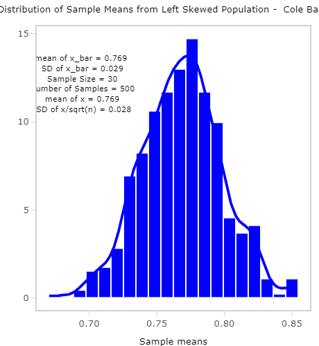

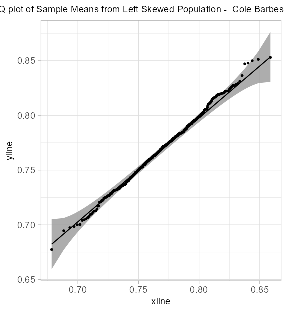

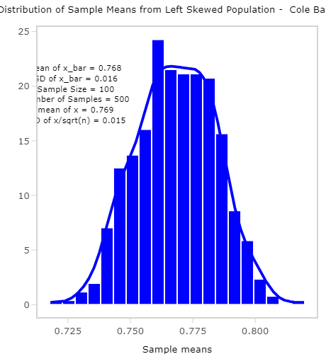

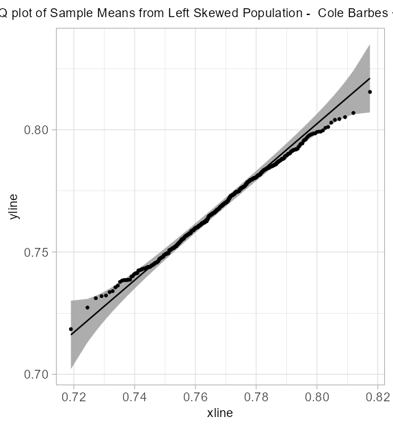

7. Comparing results on questions 4, 5, and 6. How does the sample size affect the results

   ```
   Higher sample sizes are more likely to create a more normal distribution. Lower sample sizes are less likely to create a normal distribution.
   ```

### Bimodal

2. Go to the “Population Distribution” tab, download the distribution plot and name it as “pop_normal.png”, then insert the image below.

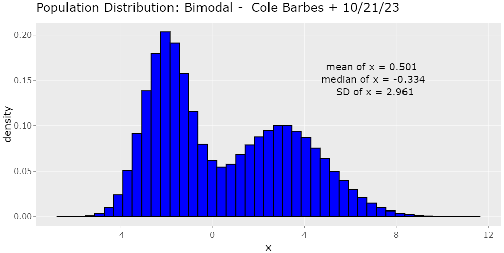

3. Based on the population distribution plot, answer the questions: what is the mean and standard deviation of this “parent” distribution, does it satisfy the assumptions? (specify which conditions are satisfied, especially 3a or 3b)

4. Go to the “Sampling Distribution - Sample Mean” tab, download the histogram and QQ-plot (for QQ-plot, you may need to right click you mouse on that plot, and click “Save image as…”). Name the plots as “sample_hist_normal_n5.png” and “sample_qq_normal_n5.png” (n5 means sample size n=5). Then insert the plots below

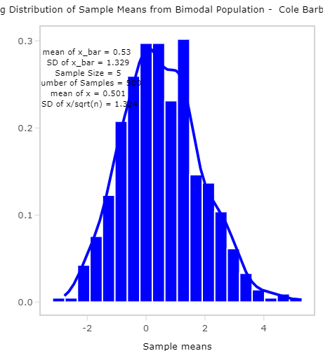

   Sample histogram bimodal

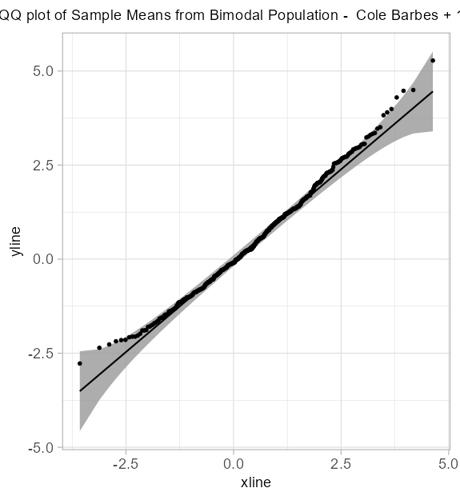

   Sample QQ plot bimodal

5. Based on the histogram and QQ_plot, answer the questions: what is the mean and standard deviation of $\overline{X}$? Do they (approximately) equal to the population mean and $\sigma/\sqrt(n)$, respectively? Based on the histogram and QQ_plot, determine whether the sampling distribution of sample means is approximately normal distributed.

   (In the case when the calculation results on the histogram are covered by the image, move you mouse to the plot, use the “pan” pop-up icon and/or “zoom in” pop_up icon to get a clearer view)

   ```
   mean of xbar is 0.53, standard deviation of xbar is 1.329 . mean of x is 0.501, sd/sqrt(n) is 1.324. it seems the means do match and the sd and the sd/sqrt(n) approximately match. The sampling distribution of sample means is approximately normal.
   ```

6. Keep the Population Distribution as “Normal”and the Number of samples as 500. But change the Sample Size to 30 and 100. Then answer questions 4 and 5 respectively. (when you download the plots, make sure to adjust the name to n30 and n100, respectively)

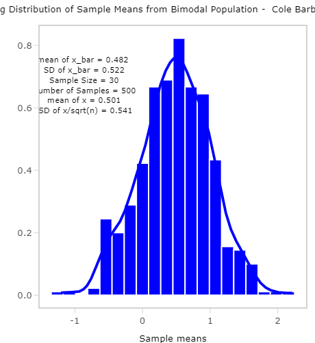

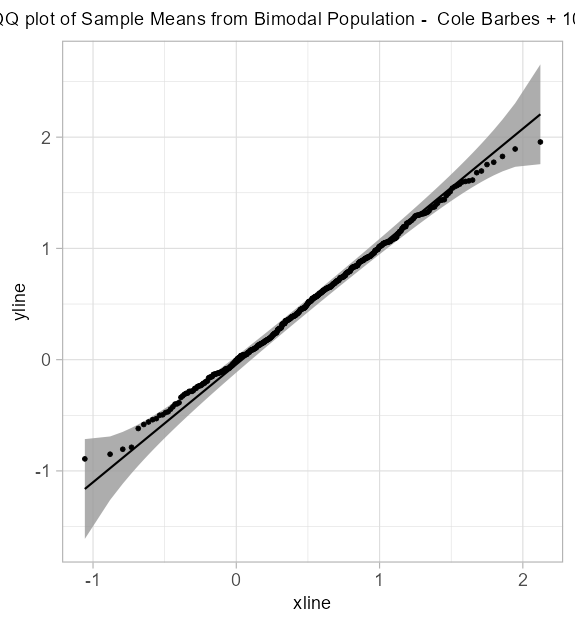

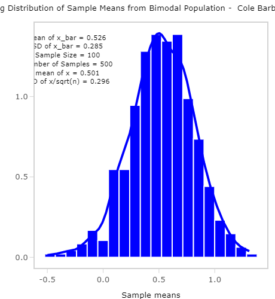

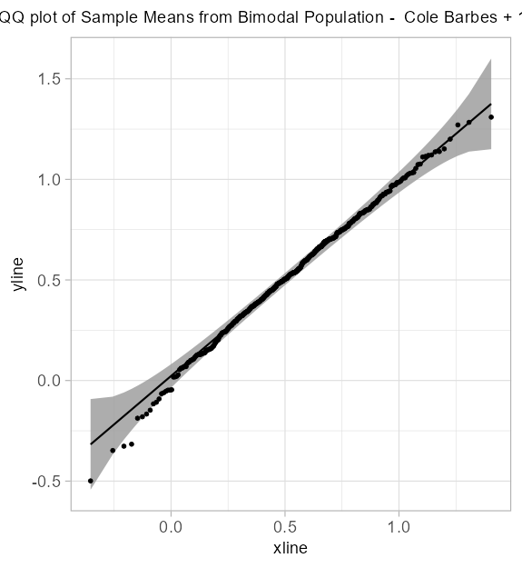

7. Comparing results on questions 4, 5, and 6. How does the sample size affect the results?

   ```
   Higher sample sizes are more likely to create a more normal distribution. Lower sample sizes are less likely to create a normal distribution.
   ```

**End of Assignment 3**

# Part III: Sampling Distributions of Sample Means: When Assumptions are NOT Satisfied

In part II, the “parent” distributions we selected in fact satisfied the assumptions needed for the Central Limit Theorem. But what if one or some of the assumptions are not satisfied? Will the Central Limit Theorem still hold? Let’s consider a particular distribution: **Cauchy Distribution**.

One interesting facts about Cauchy distribution is that, it does NOT have defined mean or standard deviation, thus assumptions 1 and 2 are not satisfied. Let’s explore the properties of the sampling distribution of sample means by completing the following assignment.

## Assignment 4

Set the Population Distribution to “Cauchy”. Then Answer all questions in Assignment 2

2. Go to the “Population Distribution” tab, download the distribution plot and name it as “pop_normal.png”, then insert the image below.

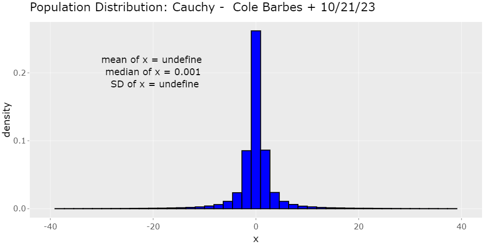

   Population cauchy

3. Based on the population distribution plot, answer the questions: what is the mean and standard deviation of this “parent” distribution, does it satisfy the assumptions? (specify which conditions are satisfied, especially 3a or 3b)

   ```
   Mean = undefine, Standard Deviation = undefined . unable to make assumption
   ```

4. Go to the “Sampling Distribution - Sample Mean” tab, download the histogram and QQ-plot (for QQ-plot, you may need to right click you mouse on that plot, and click “Save image as…”). Name the plots as “sample_hist_normal_n5.png” and “sample_qq_normal_n5.png” (n5 means sample size n=5). Then insert the plots below

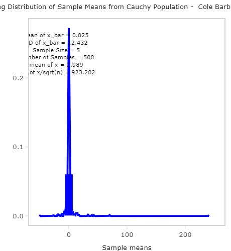

   Sample histogram cauchy

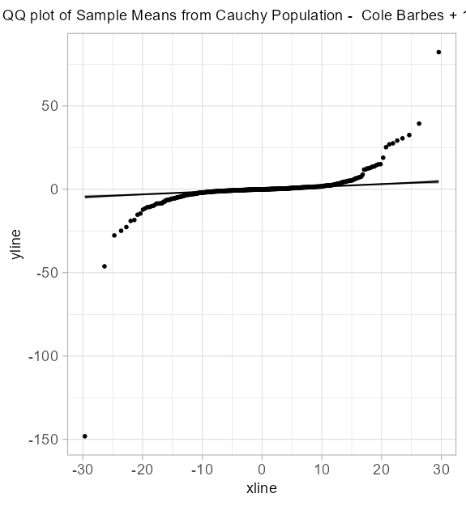

   Sample QQ plot cauchy

5. Based on the histogram and QQ_plot, answer the questions: what is the mean and standard deviation of $\overline{X}$? Do they (approximately) equal to the population mean and $\sigma/\sqrt(n)$, respectively? Based on the histogram and QQ_plot, determine whether the sampling distribution of sample means is approximately normal distributed.

   (In the case when the calculation results on the histogram are covered by the image, move you mouse to the plot, use the “pan” pop-up icon and/or “zoom in” pop_up icon to get a clearer view)

6. Keep the Population Distribution as “Normal”and the Number of samples as 500. But change the Sample Size to 30 and 100. Then answer questions 4 and 5 respectively. (when you download the plots, make sure to adjust the name to n30 and n100, respectively)

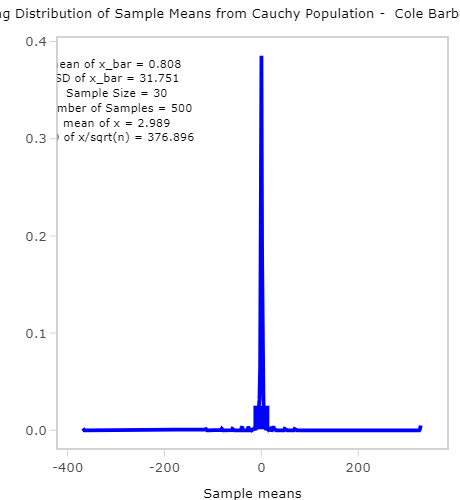

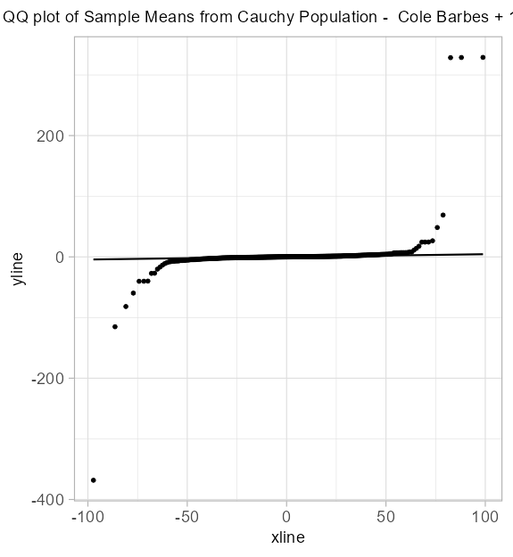

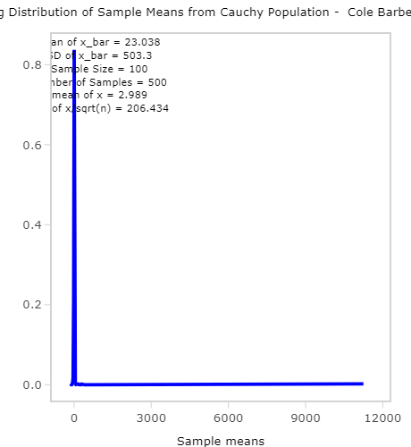

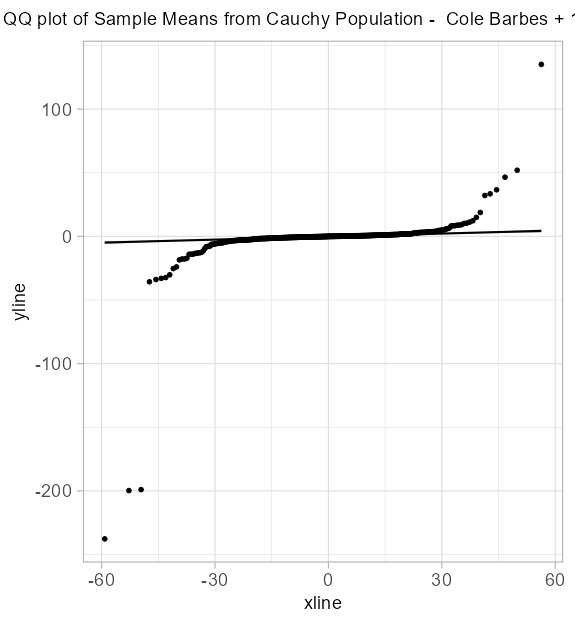

7. Comparing results on questions 4, 5, and 6. How does the sample size affect the results?

   ```  
   The cauchy seems to become more variable with higher sample sizes.

   ```

**End of Assignment 4**

So, what can we do when assumption 1 and/or 2 are not satisfied? Interestingly, we can have a “Central Limit Theorem” for **Sample Medians** (we are dealing with sample means only by far). Of course, the sample medians version CLT also require OTHER assumptions. We don’t go into the details here, but for the case of Cauchy, we can say the assumptions are satisfied. In this version, the mean of the sampling distribution of the sample medians is the population median, and the standard deviation is proportional to $1/\sqrt{n}$.

## Assignment 5

1. Go to the tab “Sampling Distribution - Sample Median”
2. Set the Population Distribution as “Cauchy”, Number of samples as 500, then change sample size as 10, 50, 100, and 300 respectively.
3. For each selected sample size, download the histogram and QQ-plot, then insert below.

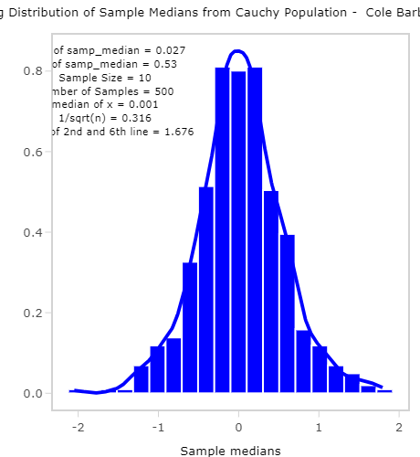

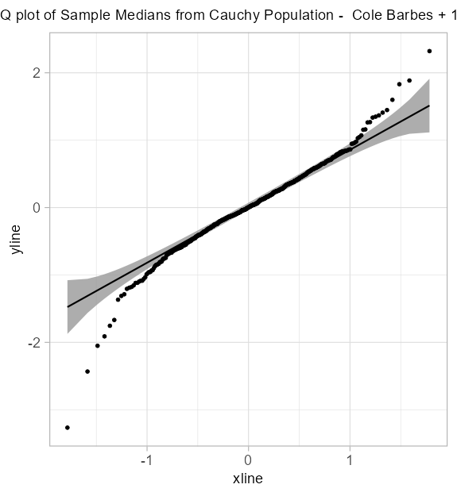

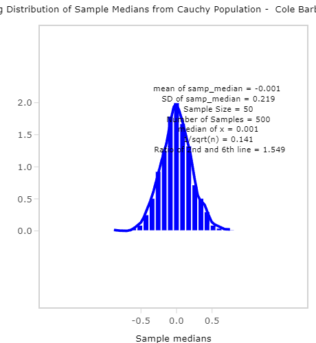

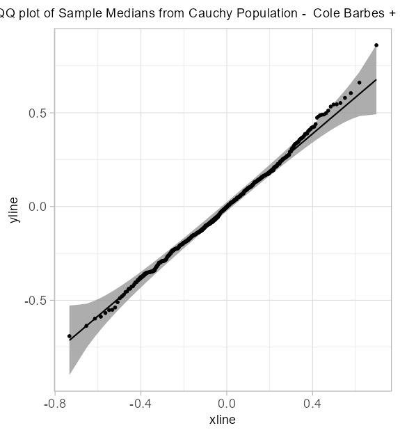

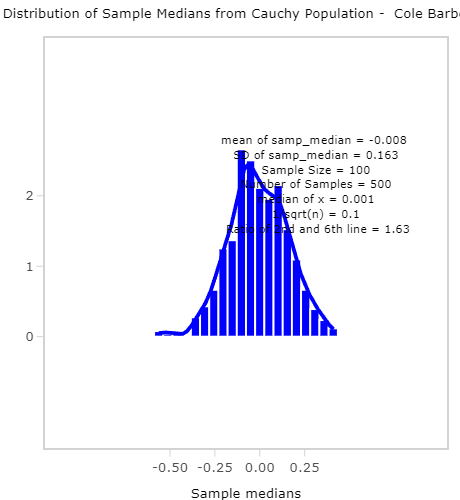

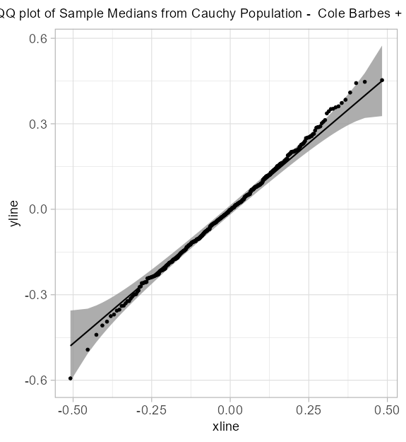

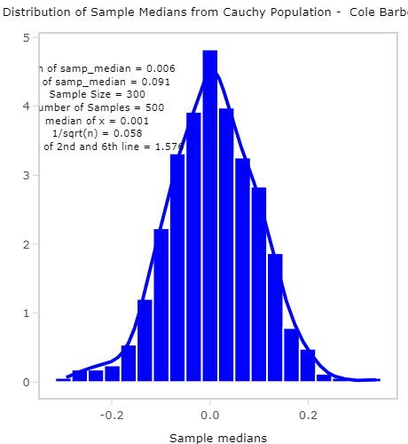

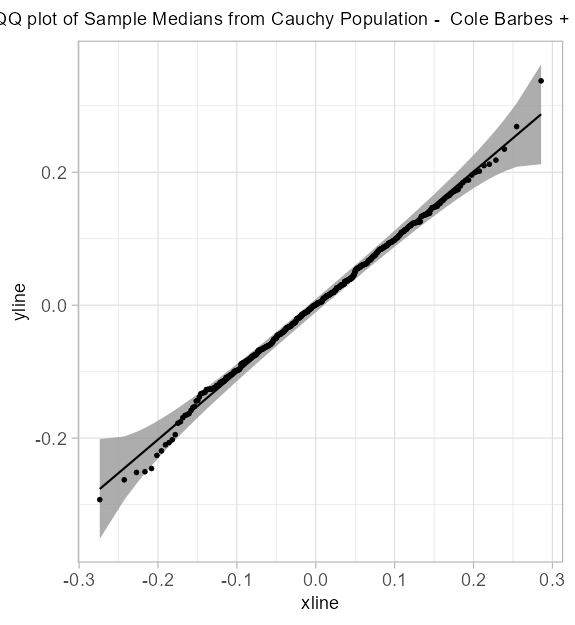

4. For each selected sample size, compare the “mean of samp_median” and “median of x” on the histogram. Then check if the “Ratio of 2nd and 6th line” are approximately equal to each others for different sample size. What is your observations.

5. For each selected sample size, is the sampling distribution of sample median approximately normal? How does the sample size increasing affect the normality approaching?

   ```
   The sampling distribution of sample median is approximately normal. sample size increase causes the data to become more normal.
   ```

**End of Assignment 5**

# Part IV: Knit this markdown file to a html report

After you complete all the above assignments, click the Knit button to create a html report. Submit that html report.